# PASS1A (Rat) Metabolomics: Site-Specific EDA–Mayo Clinic

Steep

10/12/2020

##### CSS Styling

```r
writeLines("td, th { padding : 3px } th { background-color:white; color:black; border:1px solid black; text-align:center } td {color:black; border:1px solid black; word-wrap:break-word; white-space:nowrap; overflow: hidden; text-overflow: ellipsis; max-width:300px; text-align:left}", con= "../css/style.css")
```

## Goals of Analysis

- Identify biological replicates from Mayo across tissues
- Compare replicate sample pairs
  - Identify metabolites with missing values
  - Plot and measure correlation of metabolite abundances before and after correlation
  - Perform PCA analysis between sets of replicate pairs

#### Mayo-specific Annotations

- All targeted
- No normalization
- No drift correction
- No imputation
- Samples were divided into batches of ~20 for analysis

#### Questions for Mayo:

- What was the role of QC_POOLED and QC_REFERENCE samples?
- How were QC samples divided across runs?
- “raw_file” seems to represent a date and an additiona number (date_#)
  - What is the significance of this number? Does it represent a sample order
- How was “sample_order” determined?
- How were batches divided across samples and QCs?
- Why were some tissues replicated?
- Demonstrate correlation (or lack thereof) for certain replicate runs.

### Setup the Environment

```r
################################################################################
##### Resources and Dependencies ###############################################
################################################################################

# To Render the Markdown, run this line in console
#rmarkdown::render('/Volumes/Frishman_4TB/motrpac/20200915_metabolomics-pass1a/scripts/20201012_pass1a-metabolomics-data-cleanup_steep.Rmd', output_file = '/Volumes/Frishman_4TB/motrpac/20200915_metabolomics-pass1a/reports/mayo_clinic/20201012_replicate-analysis-AAll-tissues-Mayo-Clinic_steep.html')

# Set the working directory
#############################################################################
COMP <- "MacBook"
#COMP <- "GreatLakes"
if(COMP == "MacBook"){
        # MacBook
        WD <- '/Volumes/Frishman_4TB/motrpac/20200915_metabolomics-pass1a'
}else if(COMP == "GreatLakes"){
        # MichMed
        WD <- '/home/acsteep/motrpac/20200915_metabolomics-pass1a'
}

#setwd(WD)

# Load the dependencies
#source("https://bioconductor.org/biocLite.R")
#BiocManager::install("org.Rn.eg.db")
#install.packages("kableExtra")

# Load dependencies
pacs...man <- c("tidyverse", "data.table","rlang","RColorBrewer","MASS","sfsmisc",
                "pheatmap","caret","ggforce","RANN","kableExtra","gtools","combinat",
                "knitr","markdown","rmarkdown")
for(pac in pacs...man){
  suppressWarnings(suppressPackageStartupMessages(library(pac, character.only = TRUE)))
}
# lapply(pacs...man, FUN = function(X) {
#         do.call("library", list(X)) })

############################################################
##### Functions ############################################
############################################################

# Name functions
select <- dplyr::select
counts <- DESeq2::counts
map <- purrr::map
desc <- dplyr::desc
arrange <- dplyr::arrange
melt <- reshape2::melt
mutate <- dplyr::mutate

# Global options
options(dplyr.print_max = 100)
options(scipen=10000)

# Source the functions
source(paste0(WD,'/functions/not_in.R'))
source(paste0(WD,'/functions/rat_mouse_ortho.R'))
source(paste0(WD,'/functions/mouse2rat_ortho.R'))
source(paste0(WD,'/functions/lmp.R'))
source(paste0(WD,'/functions/cor_PC_1_6.R'))
source(paste0(WD,'/functions/elbow_finder.R'))
source(paste0(WD,'/functions/cor_outlier2.R'))
source(paste0(WD,'/functions/DissimilarityMatrixNominal.R'))
source(paste0(WD,'/functions/lm_eqn.R'))
source(paste0(WD,'/functions/reorder_cormat.R'))
source(paste0(WD,'/functions/save_pheatmap_pdf.R'))
source(paste0(WD,'/functions/modeav.R'))
source(paste0(WD,'/functions/count_na.R'))
source(paste0(WD,'/functions/se_mean.R'))
source(paste0(WD,'/functions/Mode.R'))
source(paste0(WD,'/functions/NumericSummaryStats.R'))
source(paste0(WD,'/functions/AutoScaleMatrix.R'))
source(paste0(WD,'/functions/ReverseAutoScaleMatrix.R'))
source(paste0(WD,'/functions/CenterMatrix.R'))
source(paste0(WD,'/functions/RangeScaleMatrix.R'))
source(paste0(WD,'/functions/ParetoScaleMatrix.R'))
source(paste0(WD,'/functions/VastScaleMatrix.R'))
source(paste0(WD,'/functions/LevelScaleMatrix.R'))
source(paste0(WD,'/functions/Log10Matrix.R'))
source(paste0(WD,'/functions/PowerMatrix.R'))
```

### Load the Data

```r
# Load the Data
################################################################################
# Files
metadata_rds <- paste0(WD, '/data/20201010_pass1a-metabolomics-metadata-table_steep.rds')
# Load Data
metadata_df <- readRDS(file = metadata_rds)

# Start the clock
ptm <- proc.time()
# Takes 21+ seconds (881.6 Mb) 1073+ seconds for (7.5Gb)
#countdata_rds <- paste0(WD, #'/data/20201010_pass1a-metabolomics-countdata-nested_steep.rds')

# Load a specific tissues count data
# Liver takes 230 seconds (4 min)
#countdata_rds <- paste0(WD, '/data/20201010_pass1a-metabolomics-countdata-nested-',tissue,'_steep.rds')

# Load a specific metabolite family count data
# ac takes 2 seconds
# hilicpos takes 453 seconds (on MB) or 260 seconds (on GL with 40 MB 2 cores)
# All data (original + autoscaled) takes 170 seconds on MB
countdata_rds <- paste0(WD, '/data/20201010_pass1a-metabolomics-countdata-nested_steep.rds')

# Load the data
countdata_df <- readRDS(file = countdata_rds)

# Stop the clock
#proc.time() - ptm
```

### Metadata Format

```r
metadata_df %>%
  head %>%
  knitr::kable(format = "html") %>%
  scroll_box(width = "100%", height = "200px")
```

| OME | DATASET | TISSUE | METAB_FAMILY | NAMED | STUDY_INSTITUTE | STUDY_TITLE | STUDY_TYPE | STUDY_SUMMARY | STUDY_DEPARTMENT | STUDY_LABORATORY | STUDY_LAST_NAME | ST_NUM_GROUPS | SUBMIT_DATE | STUDY_COMMENTS | SUBJECT_TYPE | SUBJECT_SPECIES | SAMPLEPREP_SUMMARY | SAMPLEPREP_PROTOCOL_FILENAME | CH_CHROMATOGRAPHY_TYPE | CH_INSTRUMENT_NAME | CH_COLUMN_NAME | CH_METHODS_FILENAME | CH_SUMMARY | MS_INSTRUMENT_TYPE | MS_INSTRUMENT_NAME | MS_TYPE | MS_ION_MODE | MS_UNITS | MS_COMMENTS | … |
| --- | --- | --- | --- | --- | --- | --- | --- | --- | --- | --- | --- | --- | --- | --- | --- | --- | --- | --- | --- | --- | --- | --- | --- | --- | --- | --- | --- | --- | --- | --- |
| metabolomics | targeted | plasma | 3hib | named | Duke University | PASS 1A | Animal | exercised vs. sedentary | Duke Molecular Physiology Institute | Metabolomics Core Laboratory | Ilkayeva | NA | NA |  | animal | rat | 50 �l of plasma or 100 �l of tissue homogenate prepared at 50 mg of wet tissue per 1 ml of homogenate in 50% acetonitrile/0.3% formic acid in water containing an isotopically labeled internal standard… | NA | RPC | Waters Acquity UPLC system | “Waters Acquity UPLC HSS T3 Column, 1.8 �m, 2.1 � 100 mm” | NA | “The analytical column is used at 30�C, 10 �l of the sample are injected onto the column, and eluted isocratically at 95% eluent A (0.1 % formic acid in water) and 5% eluent B (acetonitrile) and a flo… | triple quadrupole mass spectrometer | Waters Xevo TQ-S | MRM | negative | NA | Mass transitions of m/z 103-> 73 (3-hydroxyisobutyrate or 3-HIB) and 109 -> 62 (d6-2-HIB) are monitored in a negative ion electrospray ionization mode. | … |
| metabolomics | targeted | plasma | aa | named | Duke University | PASS 1A | Animal | exercised vs. sedentary | Duke Molecular Physiology Institute | Metabolomics Core Laboratory | Ilkayeva | NA | NA |  | animal | rat | “Amino Acids are analyzed using stable isotope dilution techniques by flow injection tandem mass spectrometry. 100 microL of plasma or tissue homogenate preprared at 50 mg/ml in 50% acetonitrile/0.3% … | NA | FIC | Waters Acquity UPLC system |  | NA | “80% methanol is used as a mobile phase, the flow is 0.035 ml/min.” | triple quadrupole mass spectrometer | Waters Xevo TQD | neutral loss scan (MS/MS) | positive | NA | “Mass spectra for amino acids are obtained using neutral loss scans of m/z=102, 119, and 161. The spectra are acquired in a multi-channel analyzer (MCA) mode to improve signal-to-noise. The data are g… | … |
| metabolomics | targeted | plasma | ac | named | Duke University | PASS 1A | Animal | exercised vs. sedentary | Duke Molecular Physiology Institute | Metabolomics Core Laboratory | Ilkayeva | NA | NA |  | animal | rat | “Acylcarnitines are analyzed using stable isotope dilution techniques by flow injection tandem mass spectrometry. 100 microL of plasma or tissue homogenate preprared at 50 mg/ml in 50% acetonitrile/0.… | NA | FIC | Waters Acquity UPLC system |  | NA | “80% methanol is used as a mobile phase, the flow is 0.035 ml/min.” | triple quadrupole mass spectrometer | Waters Xevo TQD | parent scan (MS/MS) | positive | NA | “Mass spectra for acylcarnitines are obtained using a precursor ion scan of m/z=99. The spectra are acquired in a multi-channel analyzer (MCA) mode to improve signal-to-noise. The data are generated u… | … |
| metabolomics | targeted | plasma | ac | named | Mayo Clinic | Molecular Transducers of Physical Activity Consortium (MoTrPAC) | PASS1A | “RAT samples (plasma,liver, muscle, kidney, white adipose)” | Internal Medicine | Mayo Clinic Metabolomics Resource Core (MCMRC) | Dasari | NA | NA |  | Mammal | RAT | isotope IS added, deproteinized, dry, resuspended in running buffer | NA | RPC | Waters Acquity UPLC | “Acquity UPLC BEH C8, 2.1x150mm, 1.7um” | NA | Lipids were separated by liquid chromatography with 16 minutes gradient | Triple quandrupole | “Thermo TSQ Quantiva” | MRM Multiple reaction monitoring mode | positive | NA | “Multiple reaction monitoring mode (MRM)” | … |
| metabolomics | targeted | plasma | amines | named | Mayo Clinic | Molecular Transducers of Physical Activity Consortium (MoTrPAC) | PASS1A | “RAT samples (plasma,liver, muscle, kidney, white adipose)” | Internal Medicine | Mayo Clinic Metabolomics Resource Core (MCMRC) | Dasari | NA | NA |  | Mammal | RAT | isotope internal standards(IS) added, deproteinizated, carbamate derivatized | NA | RPC | Waters Acquity UPLC | “Acquity UPLC BEH C8, 2.1x150mm, 1.7um” | NA | Analytes were chromatographically separated with 40 minutes LC gradient | Triple quandrupole | “Thermo TSQ Quantiva” | MRM Multiple reaction monitoring mode | positive | NA | “Multiple reaction monitoring mode (MRM)” | … |
| metabolomics | targeted | plasma | baiba | named | Duke University | PASS 1A | Animal | exercised vs. sedentary | Duke Molecular Physiology Institute | Metabolomics Core Laboratory | Ilkayeva | NA | NA |  | animal | rat | 50 �l of plasma or 100 �l of tissue homogenate prepared at 50 mg/ml in 50% acetonitrile/0.3% formic acid in water containing the isotopically labeled internal standard d3-BAIBA (Medical Isotopes) are … | NA | RPC | Waters Acquity UPLC system | “Waters Acquity UPLC HSS T3 Column, 1.8 �m, 2.1 � 100 mm” | NA | “The analytical column is used at 30�C. 10 �l of the sample are injected onto the column and eluted at a flow rate of 0.4 ml/min. The gradient begins with 95% eluent A (0.1 % formic acid in water) and… | triple quadrupole mass spectrometer | Waters Xevo TQ-S | MRM | positive | NA | Mass transitions of m/z 160 -> 86 (3-amino-isobutanoate or BAIBA) and 163->89 (d3-BAIBA) are monitored in a positive ion electrospray ionization mode. | … |

### Count Data

```r
countdata_df %>%
  head %>%
  knitr::kable(format = "html") %>%
  scroll_box(width = "100%", height = "200px")
```

| DATASET | TISSUE | METAB_FAMILY | NAMED | STUDY_INSTITUTE | CH_CHROMATOGRAPHY_TYPE | MS_TYPE | MS_ION_MODE | COUNT_DATA | SAMPLE_DATA | METABOLITE_DATA |
| --- | --- | --- | --- | --- | --- | --- | --- | --- | --- | --- |
| targeted | plasma | 3hib | named | Duke University | RPC | MRM | negative | 3-Hydroxyisobutyric acid, 3-Hydroxyisobutyric acid, 3-Hydroxyisobutyric acid, 3-Hydroxyisobutyric acid, 3-Hydroxyisobutyric acid, 3-Hydroxyisobutyric acid, 3-Hydroxyisobutyric acid, 3-Hydroxyisobutyri… | 90008013107 , 90141013107 , 90047013107 , 90157013107 , 90134013107 , 90043013107 , 90028013107 , 90138013107 , 90031013107 , 90041013107 , 90110013107 , 90148013107 , 90044013107 , 90119013107 , 9002… | 3-hydroxyisobutyrate , 3-Hydroxyisobutyric acid, NA , 104.0473 , NA , C4H8O3 |
| targeted | plasma | aa | named | Duke University | FIC | neutral loss scan (MS/MS) | positive | Glycine , Alanine , Serine , Proline , Valine , Leucine/Isoleucine, Methionine , Histidine , Phenylalanine , Tyrosine , Aspartic acid , Glutamic acid , Ornithine , Citrulline , Arginine , Glycine , Al… | 90008013107 , 90141013107 , 90047013107 , 90157013107 , 90134013107 , 90043013107 , 90028013107 , 90138013107 , 90031013107 , 90041013107 , 90110013107 , 90148013107 , 90044013107 , 90119013107 , 9002… | alanine , arginine , aspartate , citrulline , glutamate , glycine , histidine , leucine+isoleucine, methionine , ornithine , phenylalanine , proline , serine , tyrosine , valine , Alanine , Arginine ,… |
| targeted | plasma | ac | named | Duke University | FIC | parent scan (MS/MS) | positive | CAR(2:0) , CAR(3:0) , CAR(4:0) , CAR(5:1) , CAR(4:0(OH)) , CAR(6:0) , CAR(DC3:0)/CAR(5:0(OH)) [Methyl esters] , CAR(DC4:0)/CAR(DC3:0(2Me)) [Methyl esters] , CAR(8:1) , CAR(8:0) , CAR(DC5:0) , CAR(DC6:… | 90008013107 , 90141013107 , 90047013107 , 90157013107 , 90134013107 , 90043013107 , 90028013107 , 90138013107 , 90031013107 , 90041013107 , 90110013107 , 90148013107 , 90044013107 , 90119013107 , 9002… | Car(2:0) , Car(3:0) , Car(4:0) isomers , Car(4:0-OH) , Car(4:0, 4-COOH) , Car(5:1) , Car(6:0) , Car(6:0, 6-COOH) , Car(8:0) , Car(7:1-COOH) , Car(8:1) , Car(10:0) , Car(10:1) , Car(10:2) , Car(10:3) ,… |
| targeted | plasma | ac | named | Mayo Clinic | RPC | MRM Multiple reaction monitoring mode | positive | CAR(2:0) , CAR(4:0) , Carnitine , CAR(5:0) , CAR(12:0) , CAR(14:0) , CAR(8:0) , CAR(18:1) , CAR(16:0) , CAR(3:0) , CAR(18:0) , CAR(2:0) , CAR(4:0) , Carnitine , CAR(5:0) , CAR(12:0) , CAR(14:0) , CAR(… | 90001013110 , 90141013110 , 90023013110 , 90015013110 , 90139013110 , 90020013110 , 90145013110 , 90152013110 , 90109013110 , 90148013110 , 90114013110 , 90046013110 , 90009013110 , 90053013110 , 9011… | Acetylcarnitine , Butyrylcarnitine , Carnitine , Isovalerylcarnitine, Lauroylcarnitine , Myristoylcarnitine , Octanoylcarnitine , Oleoylcarnitine , Palmitoylcarnitine , Propionylcarnitine , Stearoylca… |
| targeted | plasma | amines | named | Mayo Clinic | RPC | MRM Multiple reaction monitoring mode | positive | 1-Methylhistidine , 3-Methylhistidine , Alanine , Anserine , Arginine , Asparagine , Aspartic acid , Carnosine , Citrulline , Cystathionine , Cysteine , Ethanolamine , Glutamic acid , Glutamine , Glyc… | 90001013110 , 90141013110 , 90023013110 , 90015013110 , 90139013110 , 90020013110 , 90145013110 , 90152013110 , 90109013110 , 90148013110 , 90114013110 , 90046013110 , 90009013110 , 90053013110 , 9011… | 1-Methylhistidine , 3-Methylhistidine , Alanine , alpha-Amino-N-butyric-acid, alpha-Aminoadipic-acid , Anserine , Arginine , Asparagine , Aspartic Acid , beta-Alanine , beta-Aminoisobutyric-acid , Car… |
| targeted | plasma | baiba | named | Duke University | RPC | MRM | positive | 3-Amino-isobutanoic acid, 3-Amino-isobutanoic acid, 3-Amino-isobutanoic acid, 3-Amino-isobutanoic acid, 3-Amino-isobutanoic acid, 3-Amino-isobutanoic acid, 3-Amino-isobutanoic acid, 3-Amino-isobutanoi… | 90008013107 , 90141013107 , 90047013107 , 90157013107 , 90134013107 , 90043013107 , 90028013107 , 90138013107 , 90031013107 , 90041013107 , 90110013107 , 90148013107 , 90044013107 , 90119013107 , 9002… | 3-amino-isobutanoate , 3-Amino-isobutanoic acid, NA , 103.0633 , NA , C4H9NO2 |

### Load & Incorporate the Phenotype Data

```r
# Load the phenotype data
pheno_obj <- paste0(WD,"/data/20201021_pass1a-06-pheno-viallabel_steep.rds")
pheno_df <- readRDS(pheno_obj)

# Set a vector for Exercise/Control Levels and Colors
ec_levels <- c('Exercise - IPE',
               'Exercise - 0.5 hr',
               'Exercise - 1 hr',
               'Exercise - 4 hr',
               'Exercise - 7 hr',
               'Exercise - 24 hr',
               'Exercise - 48 hr',
               'Control - IPE',
               'Control - 7 hr')
ec_colors <- c('gold',
               'darkgoldenrod1',
               'orange',
               'darkorange',
               'darkorange2',
               'darkorange3',
               'darkorange4',
               'steelblue1',
               'steelblue4')

pheno_df %>%
  head(n = 20) %>%
  knitr::kable(format = "html") %>%
  scroll_box(width = "100%", height = "200px")
```

| pid | bid | labelid | viallabel | Key.protocol | Key.agegroup | Key.d_arrive | Key.d_sacrifice | Key.intervention | Key.sacrificetime | Key.anirandgroup | Key.sitename | Registration.d_visit | Registration.days_visit | Registration.staffid | Registration.siteid | Registration.formname | Registration.versionnbr | Registration.ratid | Registration.d_arrive | Registration.days_arrive | Registration.batchnumber | Registration.d_reverselight | Registration.days_reverselight | Registration.d_birth | Registration.days_birth | Registration.sex | Registration.weight | Registration.cagenumber | Registration.comments | … |
| --- | --- | --- | --- | --- | --- | --- | --- | --- | --- | --- | --- | --- | --- | --- | --- | --- | --- | --- | --- | --- | --- | --- | --- | --- | --- | --- | --- | --- | --- | --- |
| 10029028 | 90001 | 90001013001 | 90001013001 | 1 | 1 | 01MAY2018 | 18JUL2018 | 3 | 1 | Control - IPE | 910 | 19JUN2018 | 49 | 1293 | 910 | Animal Registration | 1 | 9 | 01MAY2018 | 0 | 1 | 01MAY2018 | 0 | Jan 2018 | -120 | 2 | 345 | 3M | NA | … |
| 10029028 | 90001 | 90001013101 | 90001013104 | 1 | 1 | 01MAY2018 | 18JUL2018 | 3 | 1 | Control - IPE | 910 | 19JUN2018 | 49 | 1293 | 910 | Animal Registration | 1 | 9 | 01MAY2018 | 0 | 1 | 01MAY2018 | 0 | Jan 2018 | -120 | 2 | 345 | 3M | NA | … |
| 10029028 | 90001 | 90001013101 | 90001013105 | 1 | 1 | 01MAY2018 | 18JUL2018 | 3 | 1 | Control - IPE | 910 | 19JUN2018 | 49 | 1293 | 910 | Animal Registration | 1 | 9 | 01MAY2018 | 0 | 1 | 01MAY2018 | 0 | Jan 2018 | -120 | 2 | 345 | 3M | NA | … |
| 10029028 | 90001 | 90001013101 | 90001013106 | 1 | 1 | 01MAY2018 | 18JUL2018 | 3 | 1 | Control - IPE | 910 | 19JUN2018 | 49 | 1293 | 910 | Animal Registration | 1 | 9 | 01MAY2018 | 0 | 1 | 01MAY2018 | 0 | Jan 2018 | -120 | 2 | 345 | 3M | NA | … |
| 10029028 | 90001 | 90001013101 | 90001013108 | 1 | 1 | 01MAY2018 | 18JUL2018 | 3 | 1 | Control - IPE | 910 | 19JUN2018 | 49 | 1293 | 910 | Animal Registration | 1 | 9 | 01MAY2018 | 0 | 1 | 01MAY2018 | 0 | Jan 2018 | -120 | 2 | 345 | 3M | NA | … |
| 10029028 | 90001 | 90001013101 | 90001013109 | 1 | 1 | 01MAY2018 | 18JUL2018 | 3 | 1 | Control - IPE | 910 | 19JUN2018 | 49 | 1293 | 910 | Animal Registration | 1 | 9 | 01MAY2018 | 0 | 1 | 01MAY2018 | 0 | Jan 2018 | -120 | 2 | 345 | 3M | NA | … |
| 10029028 | 90001 | 90001013102 | 90001013107 | 1 | 1 | 01MAY2018 | 18JUL2018 | 3 | 1 | Control - IPE | 910 | 19JUN2018 | 49 | 1293 | 910 | Animal Registration | 1 | 9 | 01MAY2018 | 0 | 1 | 01MAY2018 | 0 | Jan 2018 | -120 | 2 | 345 | 3M | NA | … |
| 10029028 | 90001 | 90001013102 | 90001013110 | 1 | 1 | 01MAY2018 | 18JUL2018 | 3 | 1 | Control - IPE | 910 | 19JUN2018 | 49 | 1293 | 910 | Animal Registration | 1 | 9 | 01MAY2018 | 0 | 1 | 01MAY2018 | 0 | Jan 2018 | -120 | 2 | 345 | 3M | NA | … |
| 10029028 | 90001 | 90001013301 | 90001015202 | 1 | 1 | 01MAY2018 | 18JUL2018 | 3 | 1 | Control - IPE | 910 | 19JUN2018 | 49 | 1293 | 910 | Animal Registration | 1 | 9 | 01MAY2018 | 0 | 1 | 01MAY2018 | 0 | Jan 2018 | -120 | 2 | 345 | 3M | NA | … |
| 10029028 | 90001 | 90001013301 | 90001015203 | 1 | 1 | 01MAY2018 | 18JUL2018 | 3 | 1 | Control - IPE | 910 | 19JUN2018 | 49 | 1293 | 910 | Animal Registration | 1 | 9 | 01MAY2018 | 0 | 1 | 01MAY2018 | 0 | Jan 2018 | -120 | 2 | 345 | 3M | NA | … |
| 10029028 | 90001 | 90001013301 | 90001015204 | 1 | 1 | 01MAY2018 | 18JUL2018 | 3 | 1 | Control - IPE | 910 | 19JUN2018 | 49 | 1293 | 910 | Animal Registration | 1 | 9 | 01MAY2018 | 0 | 1 | 01MAY2018 | 0 | Jan 2018 | -120 | 2 | 345 | 3M | NA | … |
| 10029028 | 90001 | 90001013301 | 90001015205 | 1 | 1 | 01MAY2018 | 18JUL2018 | 3 | 1 | Control - IPE | 910 | 19JUN2018 | 49 | 1293 | 910 | Animal Registration | 1 | 9 | 01MAY2018 | 0 | 1 | 01MAY2018 | 0 | Jan 2018 | -120 | 2 | 345 | 3M | NA | … |
| 10029028 | 90001 | 90001013301 | 90001015206 | 1 | 1 | 01MAY2018 | 18JUL2018 | 3 | 1 | Control - IPE | 910 | 19JUN2018 | 49 | 1293 | 910 | Animal Registration | 1 | 9 | 01MAY2018 | 0 | 1 | 01MAY2018 | 0 | Jan 2018 | -120 | 2 | 345 | 3M | NA | … |
| 10029028 | 90001 | 90001013402 | 90001015303 | 1 | 1 | 01MAY2018 | 18JUL2018 | 3 | 1 | Control - IPE | 910 | 19JUN2018 | 49 | 1293 | 910 | Animal Registration | 1 | 9 | 01MAY2018 | 0 | 1 | 01MAY2018 | 0 | Jan 2018 | -120 | 2 | 345 | 3M | NA | … |
| 10029028 | 90001 | 90001013402 | 90001015304 | 1 | 1 | 01MAY2018 | 18JUL2018 | 3 | 1 | Control - IPE | 910 | 19JUN2018 | 49 | 1293 | 910 | Animal Registration | 1 | 9 | 01MAY2018 | 0 | 1 | 01MAY2018 | 0 | Jan 2018 | -120 | 2 | 345 | 3M | NA | … |
| 10029028 | 90001 | 90001013501 | 90001015402 | 1 | 1 | 01MAY2018 | 18JUL2018 | 3 | 1 | Control - IPE | 910 | 19JUN2018 | 49 | 1293 | 910 | Animal Registration | 1 | 9 | 01MAY2018 | 0 | 1 | 01MAY2018 | 0 | Jan 2018 | -120 | 2 | 345 | 3M | NA | … |
| 10029028 | 90001 | 90001013501 | 90001015403 | 1 | 1 | 01MAY2018 | 18JUL2018 | 3 | 1 | Control - IPE | 910 | 19JUN2018 | 49 | 1293 | 910 | Animal Registration | 1 | 9 | 01MAY2018 | 0 | 1 | 01MAY2018 | 0 | Jan 2018 | -120 | 2 | 345 | 3M | NA | … |
| 10029028 | 90001 | 90001013601 | 90001015502 | 1 | 1 | 01MAY2018 | 18JUL2018 | 3 | 1 | Control - IPE | 910 | 19JUN2018 | 49 | 1293 | 910 | Animal Registration | 1 | 9 | 01MAY2018 | 0 | 1 | 01MAY2018 | 0 | Jan 2018 | -120 | 2 | 345 | 3M | NA | … |
| 10029028 | 90001 | 90001013601 | 90001015503 | 1 | 1 | 01MAY2018 | 18JUL2018 | 3 | 1 | Control - IPE | 910 | 19JUN2018 | 49 | 1293 | 910 | Animal Registration | 1 | 9 | 01MAY2018 | 0 | 1 | 01MAY2018 | 0 | Jan 2018 | -120 | 2 | 345 | 3M | NA | … |
| 10029028 | 90001 | 90001013601 | 90001015504 | 1 | 1 | 01MAY2018 | 18JUL2018 | 3 | 1 | Control - IPE | 910 | 19JUN2018 | 49 | 1293 | 910 | Animal Registration | 1 | 9 | 01MAY2018 | 0 | 1 | 01MAY2018 | 0 | Jan 2018 | -120 | 2 | 345 | 3M | NA | … |

### Visualize the number of samples and number of metabolites across all “named” batches

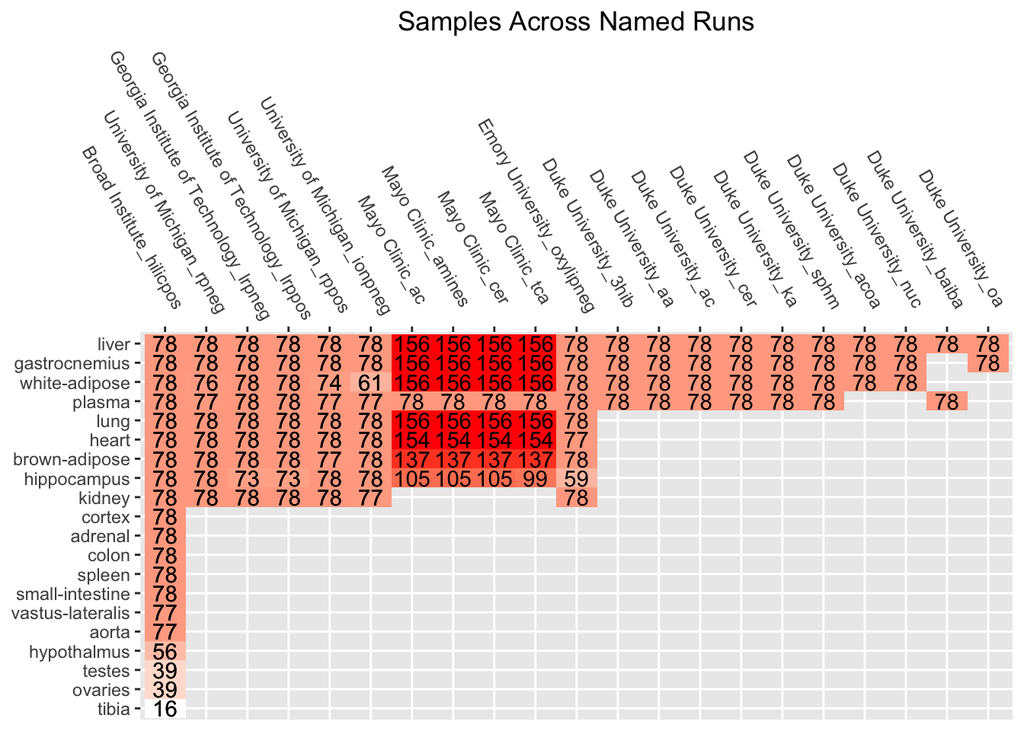

```r
# Order of Sites and metab_family
site_metab_order <- metadata_df %>%
  unite(STUDY_INSTITUTE, METAB_FAMILY, col = "SITE_METAB") %>%
  select(TISSUE,SITE_METAB,SAMPLE_N,QC_IS_N,QC_PRERUN_N,QC_BLANK_N,
          QC_POOLED_N,QC_REFERENCE_N,QC_DRIFT_N,METABOLITE_N) %>%
  group_by(SITE_METAB) %>%
  select(SITE_METAB,SAMPLE_N) %>%
  mutate(SAMPLE_SUM = sum(SAMPLE_N)) %>%
  select(SITE_METAB, SAMPLE_SUM) %>%
  arrange(desc(SAMPLE_SUM)) %>% unique() %>%
  select(SITE_METAB) %>% unlist() %>% as.character() %>% unique()

# Order of tissues
tissue_order <- metadata_df %>%
  unite(STUDY_INSTITUTE, METAB_FAMILY, col = "SITE_METAB") %>%
  select(TISSUE,SITE_METAB,SAMPLE_N,QC_IS_N,QC_PRERUN_N,QC_BLANK_N,
          QC_POOLED_N,QC_REFERENCE_N,QC_DRIFT_N,METABOLITE_N) %>%
  group_by(TISSUE) %>%
  mutate(SAMPLE_SUM = sum(SAMPLE_N)) %>%
  select(TISSUE, SAMPLE_SUM) %>%
  arrange(desc(SAMPLE_SUM)) %>% unique() %>%
  select(TISSUE) %>% unlist() %>% as.character() %>% unique() %>% rev()

# Create a plot of sample number by tissue and technology
metadata_df %>%
  unite(STUDY_INSTITUTE, METAB_FAMILY, col = "SITE_METAB") %>%
  select(TISSUE,SITE_METAB,SAMPLE_N,QC_IS_N,QC_PRERUN_N,QC_BLANK_N,
          QC_POOLED_N,QC_REFERENCE_N,QC_DRIFT_N,METABOLITE_N) %>%
  mutate(TISSUE = factor(TISSUE, levels = tissue_order)) %>%
  mutate(SITE_METAB = factor(SITE_METAB, levels = site_metab_order)) %>%
  ggplot(aes(SITE_METAB,TISSUE)) +
    geom_tile(aes(fill = SAMPLE_N)) +
    geom_text(aes(label = SAMPLE_N)) +
    scale_fill_gradient(low = "white", high = "red") +
  ggtitle("Samples Across Named Runs") +
  theme(plot.title = element_text(hjust = 0.5)) +
  theme(axis.title.x = element_blank(),
  axis.title.y = element_blank()) +
  theme(legend.position = "none") +
  scale_x_discrete(position = "top") +
  theme(axis.text.x = element_text(angle = 300, hjust = 0.9))
```

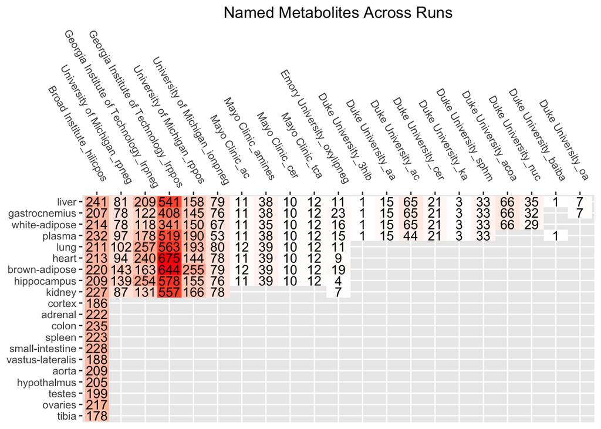

```r
# METABOLITE_NAMED_N
# Create a plot of sample number by tissue and technology
metadata_df %>%
  unite(STUDY_INSTITUTE, METAB_FAMILY, col = "SITE_METAB") %>%
  select(TISSUE,NAMED,SITE_METAB,SAMPLE_N,QC_IS_N,QC_PRERUN_N,QC_BLANK_N,
          QC_POOLED_N,QC_REFERENCE_N,QC_DRIFT_N,METABOLITE_N) %>%
  mutate(TISSUE = factor(TISSUE, levels = tissue_order)) %>%
  mutate(SITE_METAB = factor(SITE_METAB, levels = site_metab_order)) %>%
  filter(NAMED == 'named') %>%
  mutate(METABOLITE_NAMED_N = 0) %>%
  mutate(METABOLITE_NAMED_N = ifelse(NAMED == 'named', METABOLITE_N, METABOLITE_NAMED_N)) %>%
  ggplot(aes(SITE_METAB,TISSUE)) +
    geom_tile(aes(fill = METABOLITE_NAMED_N)) +
    geom_text(aes(label = METABOLITE_NAMED_N)) +
    scale_fill_gradient(low = "white", high = "red") +
  ggtitle("Named Metabolites Across Runs") +
  theme(plot.title = element_text(hjust = 0.5)) +
  theme(axis.title.x = element_blank(),
  axis.title.y = element_blank()) +
  theme(legend.position = "none") +
  scale_x_discrete(position = "top") +
  theme(axis.text.x = element_text(angle = 300, hjust = 0.9))
```

### Explore the metadata to investigate how samples were divided into measurement batches:

- “Samples were divided into batches of ~20 for analysis”

```r
# Assign Variables
################################################################################
tissue_study_institute_metab_families <- countdata_df %>%
  ungroup() %>%
  filter(STUDY_INSTITUTE == 'Mayo Clinic') %>%
  unite(STUDY_INSTITUTE,METAB_FAMILY, col = "STUDY_INSTITUTE_METAB_FAMILY") %>%
  unite(TISSUE,STUDY_INSTITUTE_METAB_FAMILY, col = TISSUE_STUDY_INSTITUTE_METAB_FAMILY) %>%
  select(TISSUE_STUDY_INSTITUTE_METAB_FAMILY) %>% unlist() %>% as.character() %>% unique()

# Are all samples divisible by 20?
metadata_df %>%
  unite(STUDY_INSTITUTE, METAB_FAMILY, col = "SITE_METAB") %>%
  filter(grepl("Mayo Clinic", SITE_METAB)) %>%
  select(TISSUE,SITE_METAB,SAMPLE_N,QC_IS_N,QC_PRERUN_N,QC_BLANK_N,
          QC_POOLED_N,QC_REFERENCE_N,QC_DRIFT_N) %>%
  mutate(ALL_SAMPLE_N = SAMPLE_N + QC_IS_N + QC_PRERUN_N + QC_BLANK_N + QC_POOLED_N +
                            QC_REFERENCE_N + QC_DRIFT_N) %>%
  mutate(ALL_SAMPLE_N_D20 = ALL_SAMPLE_N/20) %>%
  knitr::kable(format = "html") %>%
  scroll_box(width = "100%", height = "200px")
```

| TISSUE | SITE_METAB | SAMPLE_N | QC_IS_N | QC_PRERUN_N | QC_BLANK_N | QC_POOLED_N | QC_REFERENCE_N | QC_DRIFT_N | ALL_SAMPLE_N | ALL_SAMPLE_N_D20 |
| --- | --- | --- | --- | --- | --- | --- | --- | --- | --- | --- |
| plasma | Mayo Clinic_ac | 78 | 0 | 0 | 0 | 2 | 4 | 0 | 84 | 4.20 |
| plasma | Mayo Clinic_amines | 78 | 0 | 0 | 0 | 2 | 4 | 0 | 84 | 4.20 |
| plasma | Mayo Clinic_cer | 78 | 0 | 0 | 0 | 2 | 4 | 0 | 84 | 4.20 |
| plasma | Mayo Clinic_tca | 78 | 0 | 0 | 0 | 2 | 4 | 0 | 84 | 4.20 |
| hippocampus | Mayo Clinic_ac | 105 | 0 | 0 | 0 | 0 | 0 | 0 | 105 | 5.25 |
| hippocampus | Mayo Clinic_amines | 105 | 0 | 0 | 0 | 0 | 0 | 0 | 105 | 5.25 |
| hippocampus | Mayo Clinic_cer | 105 | 0 | 0 | 0 | 0 | 0 | 0 | 105 | 5.25 |
| hippocampus | Mayo Clinic_tca | 99 | 0 | 0 | 0 | 0 | 0 | 0 | 99 | 4.95 |
| gastrocnemius | Mayo Clinic_ac | 156 | 0 | 0 | 0 | 8 | 16 | 0 | 180 | 9.00 |
| gastrocnemius | Mayo Clinic_amines | 156 | 0 | 0 | 0 | 8 | 16 | 0 | 180 | 9.00 |
| gastrocnemius | Mayo Clinic_cer | 156 | 0 | 0 | 0 | 8 | 16 | 0 | 180 | 9.00 |
| gastrocnemius | Mayo Clinic_tca | 156 | 0 | 0 | 0 | 7 | 16 | 0 | 179 | 8.95 |
| heart | Mayo Clinic_ac | 154 | 0 | 0 | 0 | 0 | 0 | 0 | 154 | 7.70 |
| heart | Mayo Clinic_amines | 154 | 0 | 0 | 0 | 0 | 0 | 0 | 154 | 7.70 |
| heart | Mayo Clinic_cer | 154 | 0 | 0 | 0 | 0 | 0 | 0 | 154 | 7.70 |
| heart | Mayo Clinic_tca | 154 | 0 | 0 | 0 | 0 | 0 | 0 | 154 | 7.70 |
| lung | Mayo Clinic_ac | 156 | 0 | 0 | 0 | 0 | 0 | 0 | 156 | 7.80 |
| lung | Mayo Clinic_amines | 156 | 0 | 0 | 0 | 0 | 0 | 0 | 156 | 7.80 |
| lung | Mayo Clinic_cer | 156 | 0 | 0 | 0 | 0 | 0 | 0 | 156 | 7.80 |
| lung | Mayo Clinic_tca | 156 | 0 | 0 | 0 | 0 | 0 | 0 | 156 | 7.80 |
| liver | Mayo Clinic_ac | 156 | 0 | 0 | 0 | 24 | 0 | 0 | 180 | 9.00 |
| liver | Mayo Clinic_amines | 156 | 0 | 0 | 0 | 8 | 16 | 0 | 180 | 9.00 |
| liver | Mayo Clinic_cer | 156 | 0 | 0 | 0 | 8 | 0 | 0 | 164 | 8.20 |
| liver | Mayo Clinic_tca | 156 | 0 | 0 | 0 | 8 | 0 | 0 | 164 | 8.20 |
| brown-adipose | Mayo Clinic_ac | 137 | 0 | 0 | 0 | 0 | 0 | 0 | 137 | 6.85 |
| brown-adipose | Mayo Clinic_amines | 137 | 0 | 0 | 0 | 0 | 0 | 0 | 137 | 6.85 |
| brown-adipose | Mayo Clinic_cer | 137 | 0 | 0 | 0 | 0 | 0 | 0 | 137 | 6.85 |
| brown-adipose | Mayo Clinic_tca | 137 | 0 | 0 | 0 | 0 | 0 | 0 | 137 | 6.85 |
| white-adipose | Mayo Clinic_ac | 156 | 0 | 0 | 0 | 24 | 0 | 0 | 180 | 9.00 |
| white-adipose | Mayo Clinic_amines | 156 | 0 | 0 | 0 | 7 | 16 | 0 | 179 | 8.95 |
| white-adipose | Mayo Clinic_cer | 156 | 0 | 0 | 0 | 24 | 0 | 0 | 180 | 9.00 |
| white-adipose | Mayo Clinic_tca | 156 | 0 | 0 | 0 | 8 | 0 | 0 | 164 | 8.20 |

```r
# x %>%
#   select(ALL_SAMPLE_N_D20) %>%
#   mutate(ALL_SAMPLE_N_D20 = ALL_SAMPLE_N_D20 %>% str_split(pattern = '\\.') %>%
#            map(tail, 1) %>% unlist() %>% as.numeric()) %>%
#   mutate(ALL_SAMPLE_N_D20 = paste0('0.', as.character(ALL_SAMPLE_N_D20)) %>% as.numeric()) %>%
#   unlist() %>%
#   hist(breaks = 100) +
#   xlim(0,1)

# DEV
tissue_study_institute_metab_family <- "plasma_Mayo Clinic_ac"
for(tissue_study_institute_metab_family in tissue_study_institute_metab_families[1]){
  # Variables
  tissue <- tissue_study_institute_metab_family %>%
    str_split(pattern = '_') %>% unlist() %>% head(n=1)
  study_institute_metab_family <- tissue_study_institute_metab_family %>%
    str_remove(paste0(tissue,'_'))
  named <- 'named'

  # Collect the samples (keep QCs) & join sample order
  sample_join <- countdata_df %>%
        ungroup() %>%
        unite(STUDY_INSTITUTE,METAB_FAMILY, col = "STUDY_INSTITUTE_METAB_FAMILY") %>%
        filter(TISSUE == tissue) %>%
        filter(NAMED == named) %>%
        filter(STUDY_INSTITUTE_METAB_FAMILY == study_institute_metab_family) %>%
        unnest(SAMPLE_DATA) %>%
    select(sample_id, sample_type, sample_order, raw_file)

  # Subset Data
################################################################################
  # Collect the samples (remove QCs) & join sample order
p <- countdata_df %>%
    ungroup() %>%
    unite(STUDY_INSTITUTE,METAB_FAMILY, col = "STUDY_INSTITUTE_METAB_FAMILY") %>%
    filter(TISSUE == tissue) %>%
    filter(NAMED == named) %>%
    filter(STUDY_INSTITUTE_METAB_FAMILY == study_institute_metab_family) %>%
    unnest(COUNT_DATA) %>%
    select(-SAMPLE_DATA) %>%
    left_join(y = sample_join, by = c("viallabel" = "sample_id")) %>%
    select(STUDY_INSTITUTE_METAB_FAMILY,labelid, viallabel, pid, bid,sample_type,sample_order,raw_file) %>%
    unique() %>%
    mutate(alt_sample_order = raw_file %>% str_split(pattern = '_') %>% map(tail, 1) %>% unlist()) %>%
    arrange(raw_file, alt_sample_order)
  p %>%
  knitr::kable(format = "html") %>%
  scroll_box(width = "100%", height = "200px")
}
```

### Determine Which Sites Contain Replicates

#### Ensure that the replicate pairs contain the same labelids

```r
# Assign Variables
################################################################################
tissue_study_institute_metab_families <- countdata_df %>%
  ungroup() %>%
  unite(STUDY_INSTITUTE,METAB_FAMILY, col = "STUDY_INSTITUTE_METAB_FAMILY") %>%
  unite(TISSUE,STUDY_INSTITUTE_METAB_FAMILY, col = TISSUE_STUDY_INSTITUTE_METAB_FAMILY) %>%
  select(TISSUE_STUDY_INSTITUTE_METAB_FAMILY) %>% unlist() %>% as.character() %>% unique()

rep_out_df <- data.frame()
# DEV
# tissue_study_institute_metab_family <- "liver_Mayo Clinic_ac"
for(tissue_study_institute_metab_family in tissue_study_institute_metab_families){
  # Variables
  tissue <- tissue_study_institute_metab_family %>%
    str_split(pattern = '_') %>% unlist() %>% head(n=1)
  study_institute <- (tissue_study_institute_metab_family %>%
    str_split(pattern = '_') %>% unlist())[2]
  study_institute_metab_family <- tissue_study_institute_metab_family %>%
    str_remove(paste0(tissue,'_'))
  metab_family <- (study_institute_metab_family %>%
    str_split(pattern = '_') %>% unlist())[2]

  named <- 'named'

  # Subset Data
################################################################################
  # Collect the samples (remove QCs) & join sample order
sample_join <- countdata_df %>%
        ungroup() %>%
        unite(STUDY_INSTITUTE,METAB_FAMILY, col = "STUDY_INSTITUTE_METAB_FAMILY") %>%
        filter(TISSUE == tissue) %>%
        filter(NAMED == named) %>%
        filter(STUDY_INSTITUTE_METAB_FAMILY == study_institute_metab_family) %>%
        unnest(SAMPLE_DATA) %>%
        filter(sample_type == 'Sample') %>%
        select(sample_id, sample_order)

  # Determine the number of replicates based on viallabel ending
  reps <- countdata_df %>%
  ungroup() %>%
  unite(STUDY_INSTITUTE,METAB_FAMILY, col = "STUDY_INSTITUTE_METAB_FAMILY") %>%
  filter(TISSUE == tissue) %>%
  filter(NAMED == named) %>%
  filter(STUDY_INSTITUTE_METAB_FAMILY == study_institute_metab_family) %>%
  unnest(COUNT_DATA) %>%
  filter(viallabel %in% as.character(unlist(sample_join$sample_id))) %>%
    select(viallabel) %>% unlist() %>% as.character() %>% unique() %>%
    str_sub(-3,-1) %>% unique()

  if(length(reps) >= 2){
    # Collect number of
    #print(paste0('Number of replicates in ',tissue,' ',study_institute_metab_family,': ', length(reps)))
    #print(paste0('Replicates in ',tissue,' ',study_institute_metab_family,': ', paste(reps, collapse = ' ')))

    rep_df <- countdata_df %>%
    ungroup() %>%
    unite(STUDY_INSTITUTE,METAB_FAMILY, col = "STUDY_INSTITUTE_METAB_FAMILY") %>%
    filter(TISSUE == tissue) %>%
    filter(NAMED == named) %>%
    filter(STUDY_INSTITUTE_METAB_FAMILY == study_institute_metab_family) %>%
    unnest(COUNT_DATA) %>%
    filter(viallabel %in% as.character(unlist(sample_join$sample_id))) %>%
    #left_join(y = sample_join, by = c("viallabel" = "sample_id")) %>%
    unite(labelid, viallabel, col = "labelid_viallabel", remove = F) %>%
    mutate(REPLICATE = case_when(grepl(paste0(reps[1],"$"),labelid_viallabel) ~ reps[1],
                               grepl(paste0(reps[2],"$"),labelid_viallabel) ~ reps[2])) %>%
    select(REPLICATE,labelid_viallabel, labelid, viallabel, pid, bid, METABOLITE_NAME,VALUE)

    # rep_summary <- rep_df %>%
    #   mutate(REPLICATE = factor(REPLICATE)) %>%
    #   mutate(labelid_viallabel = factor(labelid_viallabel)) %>%
    #   mutate(labelid = factor(labelid)) %>%
    #   mutate(viallabel = factor(viallabel)) %>%
    #   mutate(pid = factor(pid)) %>%
    #   mutate(bid = factor(bid)) %>%
    #   mutate(METABOLITE_NAME = factor(METABOLITE_NAME)) %>%
    #   select(-VALUE) %>% unique()
    # summary(rep_summary)
    # rep_df %>% select(labelid) %>% table()

    r1_v <- rep_df %>%
    filter(REPLICATE == reps[1]) %>%
    select(labelid) %>% unlist() %>% as.character() %>% sort()
    r2_v <- rep_df %>%
    filter(REPLICATE == reps[2]) %>%
    select(labelid) %>% unlist() %>% as.character() %>% sort()
    out_df <- data.frame(TISSUE = tissue,
               STUDY_INSTITUTE = study_institute,
               METAB_FAMILY = metab_family,
               NAMED = named,
               REP_N = length(reps),
               REPS = paste(reps, collapse = ';'),
               REP_PAIR_N = sum(r1_v %in% r2_v),
               SAMPLE_N = length(c(r1_v, r2_v)))
    rep_out_df <- rbind(rep_out_df, out_df)
  }
}
rep_out_df %>%
  arrange(desc(REP_N)) %>%
  knitr::kable(format = "html") %>%
  scroll_box(width = "100%", height = "200px")
```

| TISSUE | STUDY_INSTITUTE | METAB_FAMILY | NAMED | REP_N | REPS | REP_PAIR_N | SAMPLE_N |
| --- | --- | --- | --- | --- | --- | --- | --- |
| hippocampus | Mayo Clinic | ac | named | 3 | 210;209;208 | 385 | 1111 |
| hippocampus | Mayo Clinic | amines | named | 3 | 210;209;208 | 1365 | 3939 |
| hippocampus | Mayo Clinic | cer | named | 3 | 210;209;208 | 350 | 1010 |
| hippocampus | Mayo Clinic | tca | named | 3 | 210;209;208 | 396 | 1164 |
| gastrocnemius | Mayo Clinic | ac | named | 2 | 513;512 | 858 | 1716 |
| gastrocnemius | Mayo Clinic | amines | named | 2 | 513;512 | 2964 | 5928 |
| gastrocnemius | Mayo Clinic | cer | named | 2 | 513;512 | 780 | 1560 |
| gastrocnemius | Mayo Clinic | tca | named | 2 | 513;512 | 936 | 1872 |
| heart | Mayo Clinic | ac | named | 2 | 811;812 | 847 | 1694 |
| heart | Mayo Clinic | amines | named | 2 | 811;812 | 3003 | 6006 |
| heart | Mayo Clinic | cer | named | 2 | 811;812 | 770 | 1540 |
| heart | Mayo Clinic | tca | named | 2 | 811;812 | 924 | 1848 |
| lung | Mayo Clinic | ac | named | 2 | 611;610 | 936 | 1872 |
| lung | Mayo Clinic | amines | named | 2 | 611;610 | 3042 | 6084 |
| lung | Mayo Clinic | cer | named | 2 | 611;610 | 780 | 1560 |
| lung | Mayo Clinic | tca | named | 2 | 611;610 | 936 | 1872 |
| liver | Mayo Clinic | ac | named | 2 | 811;812 | 858 | 1716 |
| liver | Mayo Clinic | amines | named | 2 | 811;812 | 2964 | 5928 |
| liver | Mayo Clinic | cer | named | 2 | 811;812 | 780 | 1560 |
| liver | Mayo Clinic | tca | named | 2 | 811;812 | 936 | 1872 |
| brown-adipose | Mayo Clinic | ac | named | 2 | 910;909 | 756 | 1644 |
| brown-adipose | Mayo Clinic | amines | named | 2 | 910;909 | 2457 | 5343 |
| brown-adipose | Mayo Clinic | cer | named | 2 | 910;909 | 630 | 1370 |
| brown-adipose | Mayo Clinic | tca | named | 2 | 910;909 | 756 | 1644 |
| white-adipose | Mayo Clinic | ac | named | 2 | 011;012 | 858 | 1716 |
| white-adipose | Mayo Clinic | amines | named | 2 | 011;012 | 2730 | 5460 |
| white-adipose | Mayo Clinic | cer | named | 2 | 011;012 | 780 | 1560 |
| white-adipose | Mayo Clinic | tca | named | 2 | 012;011 | 936 | 1872 |

##### Subset data to send to Collaborators (Matrices and Dataframes as R Objects)

```r
# Assign Variables
################################################################################
tissue_study_institute_metab_reps <- countdata_df %>%
  ungroup() %>%
  filter(STUDY_INSTITUTE == 'Mayo Clinic') %>%
  filter(TISSUE %in% c("gastrocnemius","heart","lung","liver","brown-adipose","white-adipose")) %>%
  filter(METAB_FAMILY %in% c('ac','amines','cer','tca')) %>%
  unite(STUDY_INSTITUTE,METAB_FAMILY, col = "STUDY_INSTITUTE_METAB_FAMILY") %>%
  unite(TISSUE,STUDY_INSTITUTE_METAB_FAMILY, col = TISSUE_STUDY_INSTITUTE_METAB_FAMILY) %>%
  select(TISSUE_STUDY_INSTITUTE_METAB_FAMILY) %>% unlist() %>% as.character() %>% unique()

# DEV
# tissue_study_institute_metab_rep <- "liver_Mayo Clinic_ac"
for(tissue_study_institute_metab_rep in tissue_study_institute_metab_reps){
  # Variables
  tissue <- tissue_study_institute_metab_rep %>%
    str_split(pattern = '_') %>% unlist() %>% head(n=1)
  study_institute_metab_family <- tissue_study_institute_metab_rep %>%
    str_remove(paste0(tissue,'_'))
  named <- 'named'
  tissue_study_institute_metab_rep_out <- tissue_study_institute_metab_rep %>%
    str_replace_all('_','-') %>% str_replace_all(' ','-')

  # Subset Data
################################################################################
  # Collect the samples (remove QCs) & join sample order
sample_join <- countdata_df %>%
        ungroup() %>%
        unite(STUDY_INSTITUTE,METAB_FAMILY, col = "STUDY_INSTITUTE_METAB_FAMILY") %>%
        filter(TISSUE == tissue) %>%
        filter(NAMED == named) %>%
        filter(STUDY_INSTITUTE_METAB_FAMILY == study_institute_metab_family) %>%
        unnest(SAMPLE_DATA) %>%
        filter(sample_type == 'Sample') %>%
        select(sample_id, sample_order)

  # Collect the metabolites unique to run
  metabolites <- countdata_df %>%
        ungroup() %>%
        unite(STUDY_INSTITUTE,METAB_FAMILY, col = "STUDY_INSTITUTE_METAB_FAMILY") %>%
        filter(TISSUE == tissue) %>%
        filter(NAMED == named) %>%
        filter(STUDY_INSTITUTE_METAB_FAMILY == study_institute_metab_family) %>%
        unnest(METABOLITE_DATA) %>%
        select(refmet_name) %>% unlist() %>% as.character() %>% unique()

  # Determine the number of replicates based on viallabel ending
  reps <- countdata_df %>%
  ungroup() %>%
  unite(STUDY_INSTITUTE,METAB_FAMILY, col = "STUDY_INSTITUTE_METAB_FAMILY") %>%
  filter(TISSUE == tissue) %>%
  filter(NAMED == named) %>%
  filter(STUDY_INSTITUTE_METAB_FAMILY == study_institute_metab_family) %>%
  unnest(COUNT_DATA) %>%
  filter(viallabel %in% as.character(unlist(sample_join$sample_id))) %>%
    select(viallabel) %>% unlist() %>% as.character() %>% unique() %>%
    str_sub(-3,-1) %>% unique()


  # Collect abundances in long format and annotate replicate labelids
rep_df <- countdata_df %>%
        ungroup() %>%
        unite(STUDY_INSTITUTE,METAB_FAMILY, col = "STUDY_INSTITUTE_METAB_FAMILY") %>%
        filter(TISSUE == tissue) %>%
        filter(NAMED == named) %>%
        filter(STUDY_INSTITUTE_METAB_FAMILY == study_institute_metab_family) %>%
        unnest(COUNT_DATA) %>%
        filter(viallabel %in% as.character(unlist(sample_join$sample_id))) %>%
        filter(METABOLITE_NAME %in% metabolites) %>%
        left_join(y = sample_join, by = c("viallabel" = "sample_id")) %>%
        unite(labelid, viallabel, col = "labelid_viallabel", remove = F) %>%
        mutate(REPLICATE = case_when(grepl(paste0(reps[1],"$"),labelid_viallabel) ~ reps[1],
                                     grepl(paste0(reps[2],"$"),labelid_viallabel) ~ reps[2],
                                     grepl(paste0(reps[3],"$"),labelid_viallabel) ~ reps[3]))

# Subset matrices by replicate samples
reps_mats <- rep_df %>%
  unite(labelid, viallabel, col = "labelid_viallabel", remove = F) %>%
  split(.$REPLICATE) %>%
  map(select, labelid_viallabel, METABOLITE_NAME, VALUE) %>%
  map(pivot_wider, names_from = METABOLITE_NAME, values_from = VALUE) %>%
  map(arrange, labelid_viallabel) %>%
  map(column_to_rownames, var = "labelid_viallabel") %>%
  map(as.matrix)
rep_mat1 <- reps_mats[[1]]
rep_mat2 <- reps_mats[[2]]

# Select the replicate orders as dfs
rep_ords <- rep_df %>%
  unite(labelid, viallabel, col = "labelid_viallabel", remove = F) %>%
  split(.$REPLICATE) %>%
  map(select, labelid_viallabel, sample_order) %>%
  map(unique) %>%
  map(arrange, labelid_viallabel)
rep_ord1 <- rep_ords[[1]]
rep_ord2 <- rep_ords[[2]]
x <- (row.names(rep_ord1) %>% str_split(pattern = '_') %>% map(head, n =1)) %>% unlist()
y <- (row.names(rep_ord2) %>% str_split(pattern = '_') %>% map(head, n = 1)) %>% unlist()

# Ensure that samples have the same labelid
x <- (row.names(rep_mat1) %>% str_split(pattern = '_') %>% map(head, n =1)) %>% unlist()
y <- (row.names(rep_mat2) %>% str_split(pattern = '_') %>% map(head, n = 1)) %>% unlist()
#print(tissue_study_institute_metab_rep)
#print(reps)
#print(table(x == y))
if(all(x == y)){
  # Save the matrices
  mat_file1 <- paste0(WD,'/files_to_share/20201012_replicate-analysis-',tissue_study_institute_metab_rep_out,'-reps1_steep.RDS')
  mat_file2 <- paste0(WD,'/files_to_share/20201012_replicate-analysis-',tissue_study_institute_metab_rep_out,'-reps2_steep.RDS')
  saveRDS(rep_mat1, mat_file1)
  saveRDS(rep_mat2, mat_file2)
  # Save the order files
  ord_file1 <- paste0(WD,'/files_to_share/20201012_replicate-analysis-',tissue_study_institute_metab_rep_out,'-reps1-sample-order_steep.RDS')
  ord_file2 <- paste0(WD,'/files_to_share/20201012_replicate-analysis-',tissue_study_institute_metab_rep_out,'-reps2-sample-order_steep.RDS')
  saveRDS(rep_ord1, ord_file1)
  saveRDS(rep_ord2, ord_file2)
}

}
```

### Per Run, Split the Data by duplicates and plot boxplots and matched density plot before normalization, normalize, and plot boxplots and matched density plot after normalization

#### These analyses are rendered in adjunct HTML files

- Boxplots
  - Density plot
  - Summary Statistics

# Inference:

- It seems there are differences in metabolite abundances between the replicates pairs.
  - We should consider why these samples were replicated.
    - Is it safe to assume these replicate pairs should demonstrate similar metabolite abundances and be correlated?
    - Or, were samples replicated for another reason?